# What can an LLM contribute to qualitative interpretation?

Session 3 · Qualitative analysis

Christopher Barrie · NYU Sociology

2026-09-16

## We begin with an interview, not an AI tool

T01_A · first interview segment“The grocery deliveries got us through the last week of the month. At that point I did not know who organized them.”

**Study**

Interviews with tenants involved in mutual-aid networks after a period of rent increases.

**Research question**

How do residents distinguish emergency help from political solidarity?

**Today’s problem**

How could we move from this account to a defensible interpretation?

All tenant interviews in this class are instructor-authored synthetic material.

## The source record tells us how to read the passage

**Source information**Participant: T01Excerpt: T01_APosition: early in interviewBefore: discussion of a rent increaseAfter: later account of childcare exchanges and tenant meetings

“The grocery deliveries got us through the last week of the month. At that point I did not know who organized them.”

The speaker received practical help before knowing the people behind it. Whether this later became solidarity is still an open question.

## Qualitative analysis connects accounts, contexts, and concepts

**Meaning in context**

What does the passage mean within this interview and social setting?

**Comparison**

How does this case resemble or differ from other cases and moments?

**Explanation**

What process or relationship does the comparison help us understand?

Coding helps organize the material. The larger aim is a sociological account that remains grounded in what participants said and did.

Deterding and Waters (2021); Timmermans and Tavory (2012); Viterna (2006).

## Flexible coding separates broad indexing from analytic coding

| First pass: index coding | Second pass: analytic coding |
| --- | --- |
| Organize material by broad topics connected to the interview guide. | Compare indexed passages to develop more interpretive categories. |
| Applied across the full interview in a relatively consistent way. | Can change as researchers compare cases and refine the argument. |
| Example: `RECEIVING_HELP` | Example: `HELP_BEFORE_RELATIONSHIP` |

Deterding and Waters developed this approach for large in-depth interview projects in which teams need both consistency and room for interpretation.

Deterding, N. M., and M. C. Waters. (2021). “Flexible Coding of In-depth Interviews: A Twenty-first-century Approach.” *Sociological Methods & Research* 50(2):708–739. https://doi.org/10.1177/0049124118799377.

## Index coding gives us a reliable route back to the material

T01_A“The grocery deliveries got us through the last week of the month.”

RECEIVING_HELP

This broad code gathers passages about receiving food, childcare, repairs, or emergency funds.

It answers: **where should we look?**

The index code does not yet tell us what receiving help meant to this participant.

## Analytic coding asks what is happening across cases

| Excerpt | What happens? | Developing analytic code |
| --- | --- | --- |
| `T01_A` | Help arrives before the recipient knows the organizers. | `HELP_BEFORE_RELATIONSHIP` |
| `T01_B` | Repeated childcare exchanges precede meeting attendance. | `REPEATED_EXCHANGE_TO_PARTICIPATION` |
| `T02_A` | Emergency support is kept separate from politics. | `HELP_WITHOUT_IDENTIFICATION` |

The code changes because the comparison changes what the researcher notices.

## Timmermans and Tavory explain how surprise can lead to theory

[figure not shown]

**Starting point:** an observation does not fit what the researcher expected.

**Analytic work:** revisit the evidence, question the concepts that made it surprising, and compare alternative explanations.

**Our case:** a tenant accepts help but explicitly rejects political identification. That case may require us to revise what we mean by participation.

Timmermans, S., and I. Tavory. (2012). “Theory Construction in Qualitative Research: From Grounded Theory to Abductive Analysis.” *Sociological Theory* 30(3):167–186. https://doi.org/10.1177/0735275112457914.

## Abductive analysis gives us three concrete moves

**Revisit**

Return to earlier passages after a later case changes the question.

**Defamiliarize**

Question the concepts that made one interpretation seem obvious.

**Compare alternatives**

Ask what else could explain the same material.

These moves are drawn from Timmermans and Tavory’s account of abductive theory construction, not a generic checklist for using AI.

Timmermans and Tavory (2012), pp. 179–182.

## Viterna shows why a list of themes is not enough

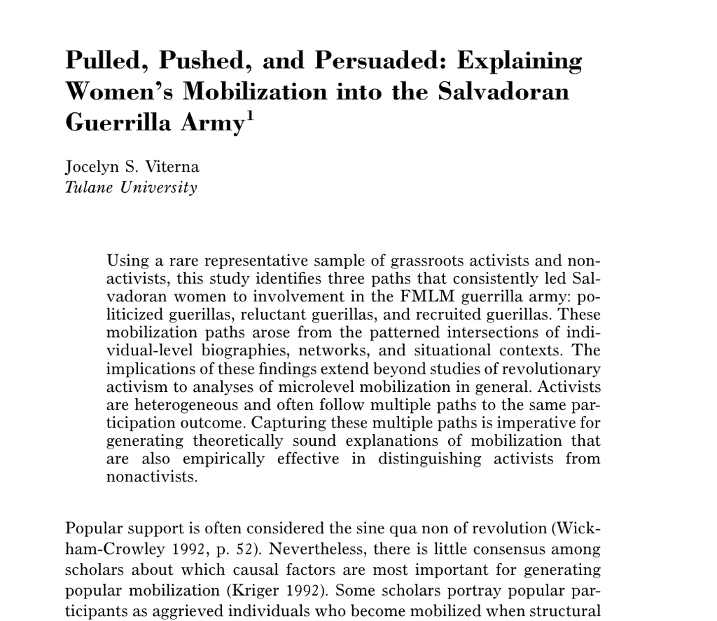

Viterna asks why women entered the Salvadoran guerrilla army through different routes.

Her evidence combines a rare sample of activists and non-activists with detailed life histories.

The substantive result is not simply that biographies, networks and repression all matter. Their patterned intersections produce different pathways into the same outcome.

Viterna, J. S. (2006). “Pulled, Pushed, and Persuaded: Explaining Women’s Mobilization into the Salvadoran Guerrilla Army.” *American Journal of Sociology* 112(1):1–45. https://doi.org/10.1086/502690.

## Her analysis moves from variables back to lives and sequences

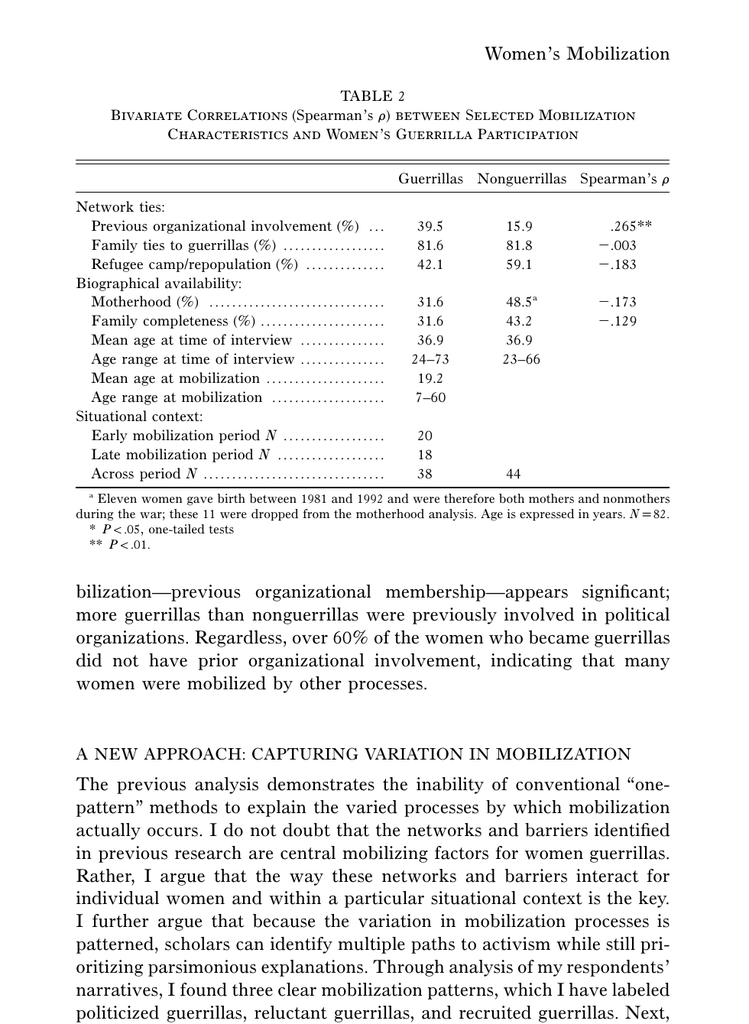

A variable-by-variable comparison finds only limited differences between guerrillas and non-guerrillas.

Viterna then returns to respondents’ narratives and identifies three paths: politicized, reluctant and recruited guerrillas.

The move matters: the same factor can have a different meaning depending on when it appears and what else accompanies it.

Viterna (2006), pp. 18–20, especially Table 2 and “A New Approach: Capturing Variation in Mobilization.”

## The comparison is made case by case, not only theme by theme

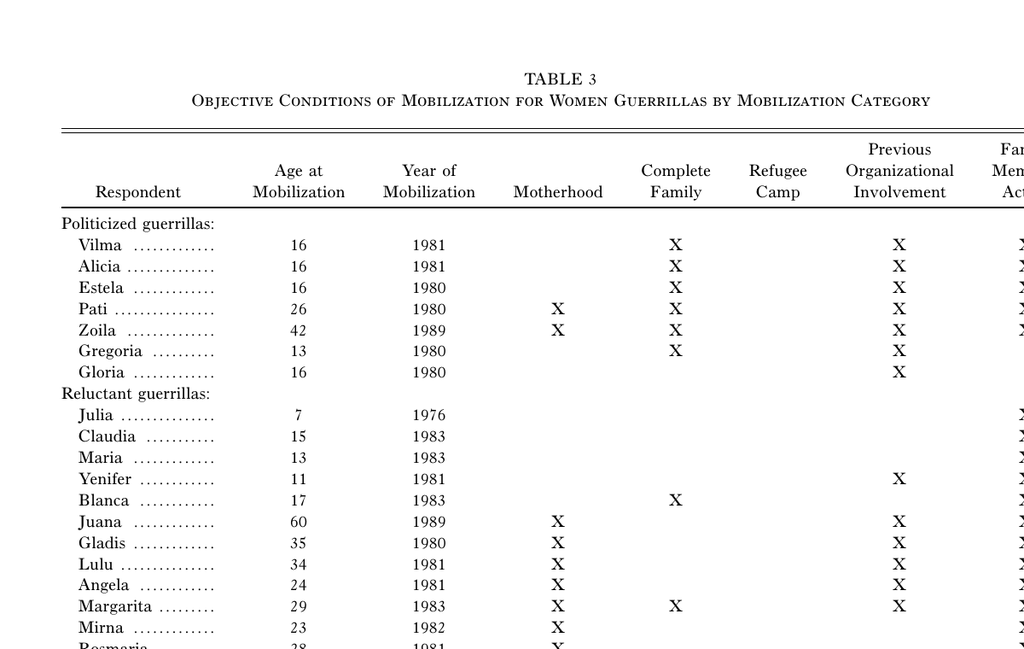

Each row is a woman and each column records part of her life history. Grouping cases by pathway makes the comparison visible.

Viterna (2006), Table 3, pp. 22–23.

## This sets a demanding standard for an LLM-assisted analysis

| If the model returns… | What is still missing? |
| --- | --- |
| “Political repression” is a theme | Which women encountered it, at what point, and through which sequence? |
| “Social networks” is a theme | Which ties recruited, constrained or failed to mobilize different women? |
| Three named pathways | The cases, comparisons and counterexamples used to justify those groupings. |

The model may help locate and compare passages. It has not reproduced the analysis unless we can inspect how cases and sequences support the explanation.

## Qualitative analysis repeatedly returns to earlier material

**Read and index**

Locate passages relevant to the question.

**Compare and code**

Ask what varies within and across cases.

**Write a memo**

Develop a possible relationship or explanation.

**Test the account**

Seek contrary cases and other explanations.

A later passage can change an earlier code, memo, or interpretation.

Deterding and Waters (2021); Timmermans and Tavory (2012); Viterna (2006).

## An LLM can assist with parts of this work

| Research activity | Possible model contribution | What the workflow must preserve |
| --- | --- | --- |
| Finding passages | Retrieve likely relevant excerpts. | Speaker, sequence, and surrounding text. |
| Applying a defined code | Suggest codes under explicit rules. | The code definition and cases where it fails. |
| Comparing cases | Place similarities and differences side by side. | Which cases were included or omitted. |
| Developing an account | Propose a candidate relationship or alternative. | Researcher memos, counterevidence, and revision history. |

Fluent themes are easy to produce. The methodological question is whether the researcher preserves the source material, comparisons, memos, and revisions needed to assess them.

## A context window is not the same as analytic memory

**Context window**

The text included in one model call: instructions, excerpts, and earlier messages that the application sends again.

A separate API call does not automatically contain material from an earlier call.

**Memory system**

An application stores earlier material, selects what seems relevant, and places it back into a later context.

What is indexed, summarized, retrieved, or dropped is a methodological decision.

Liu et al. (2024); Wu et al. (2025).

## Long context does not guarantee equal attention to every passage

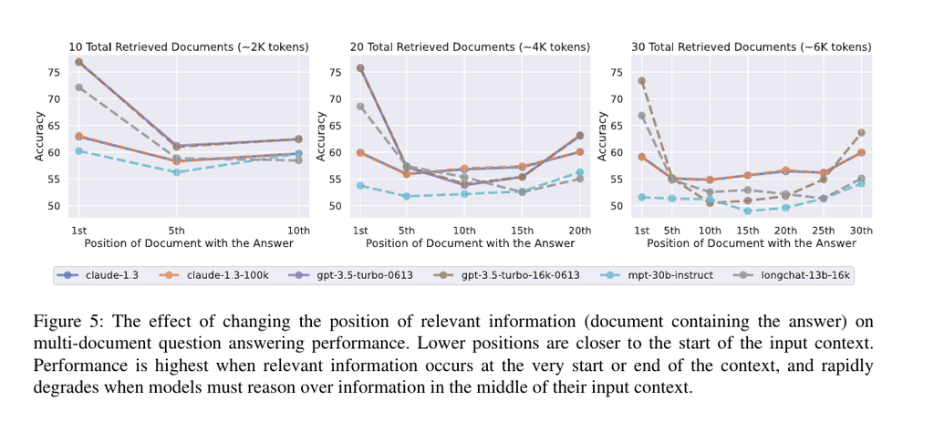

Liu and colleagues found that answer-relevant information was often used less reliably when it appeared in the middle of a long input. Supplying the full corpus is not evidence that every passage influenced the response equally.

Liu, N. F., K. Lin, J. Hewitt, et al. (2024). “Lost in the Middle: How Language Models Use Long Contexts.” *TACL* 12:157–173, selected Figure 5. https://doi.org/10.1162/tacl_a_00638.

## Long-term memory systems decide what the model sees again

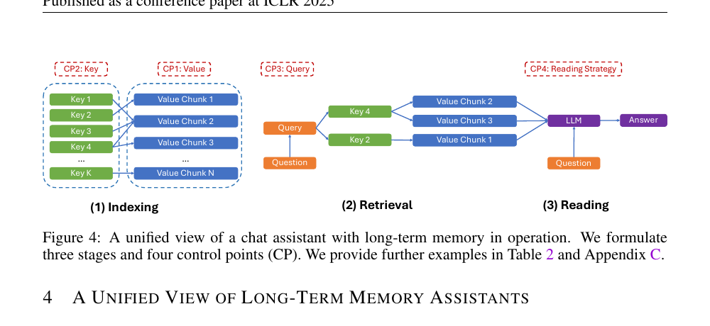

LongMemEval separates memory into indexing, retrieval, and reading. Each stage can omit or compress material. In qualitative analysis, those choices can determine which case appears relevant later.

Wu, D., H. Wang, W. Yu, et al. (2025). “LongMemEval: Benchmarking Chat Assistants on Long-Term Interactive Memory.” ICLR, Figure 4.

## Our worked example keeps the corpus deliberately small

| Study element | Course example |
| --- | --- |
| Setting | Tenants involved in neighbourhood mutual-aid networks after rent increases. |
| Material | Eight short interview excerpts from six participants. |
| Research question | How do residents distinguish emergency help from political solidarity? |
| Stored context | Participant ID, sequence, surrounding event, and excerpt text. |

The data are synthetic. The purpose is to inspect the full analytical process, not make claims about real tenants.

## We give the model a specific and limited task

**INPUT**

The research question and all eight labelled excerpts.

**REQUEST**

Propose one candidate pattern. Cite the excerpt IDs that led to it. Return JSON containing `candidate_theme`, `supporting_excerpt_ids`, and `reasoning`.

**OUTPUT STATUS**

A suggestion for the researcher to investigate—not the study’s finding.

## The model proposes a relationship among the excerpts

**CACHED SYNTHETIC MODEL OUTPUT**

“Mutual aid transforms practical dependence into political solidarity.”

The output cites `T01_B`, `T04_A`, and `T06_A`. We will check the passages, compare other cases, and decide whether the claim should be revised.

## Two of the cited passages make the proposal plausible

T01_B · months after T01_A“After a few months of taking turns with childcare, I started going to the tenants’ meetings. The first time I spoke was about the broken elevator.”

T04_A · repair exchanges“Fixing things together meant we already trusted one another when the eviction notices arrived. Six of us wrote the petition and delivered it together.”

These passages support a possible link between repeated exchange and collective action. They do not show that the transformation occurs across the corpus.

## Mehta and colleagues provide a simple empirical warning

[figure not shown]

**Material:** focus groups on sexual and reproductive health during COVID-19 in rural western Kenya.

**Comparison:** human thematic analysis and GPT-4o output.

**Finding:** broad subthemes were often relevant, but selected quotations were unreliable and sometimes altered.

**Why it comes first:** before debating interpretation, we can check whether the evidence was reproduced correctly.

Mehta, S. D., S. Paul, E. Awiti, et al. (2025). “Evaluation of Large Language Models within GenAI in Qualitative Research.” *Scientific Reports* 15:34993. https://doi.org/10.1038/s41598-025-18969-w.

## Their published examples show why quotations must be checked

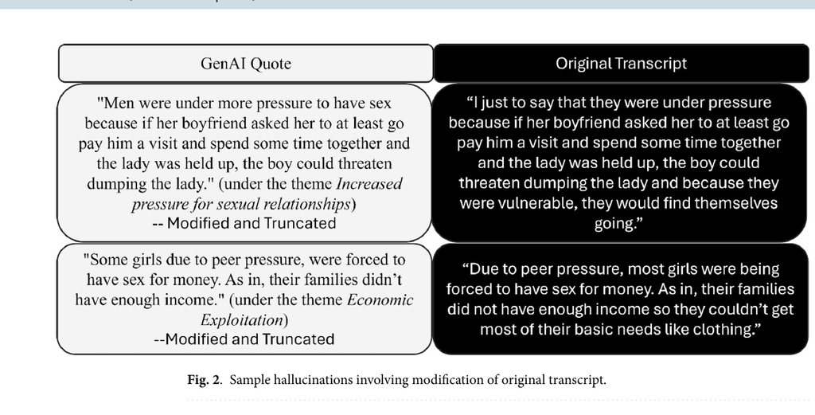

The generated quotations changed or truncated wording in ways that altered meaning. An exact-source check is therefore an essential first step.

Mehta et al. (2025), Figure 2.

## A correct quotation still leaves interpretive questions

| Question | What a passing check establishes | What remains open |
| --- | --- | --- |
| Does the excerpt ID exist? | The cited record is in the corpus. | Whether it supports the claim. |
| Is the wording exact? | The quotation was not altered. | Whether surrounding context changes its meaning. |
| Were all eight excerpts supplied? | The model could receive the full small corpus. | Whether it used the cases evenly. |

We will perform the source check in Python, then return to the qualitative work of comparison and revision.

## Than and colleagues test a bounded coding workflow

[figure not shown]

**Material:** 1,253 U.S. newsweekly articles published between 1980 and 2012.

**Task:** decide whether inequality is substantively central to each complete article.

**Models:** GPT-4 and three open models, compared with existing hand coding.

**Scope:** the study evaluates contextual classification inside a researcher-led qualitative coding workflow.

Than, N., L. Fan, T. Law, L. K. Nelson, and L. McCall. (2025). “Updating ‘The Future of Coding’: Qualitative Coding with Generative Large Language Models.” *Sociological Methods & Research* 54(3):849–888. https://doi.org/10.1177/00491241251339188.

## Their example requires reading beyond a keyword

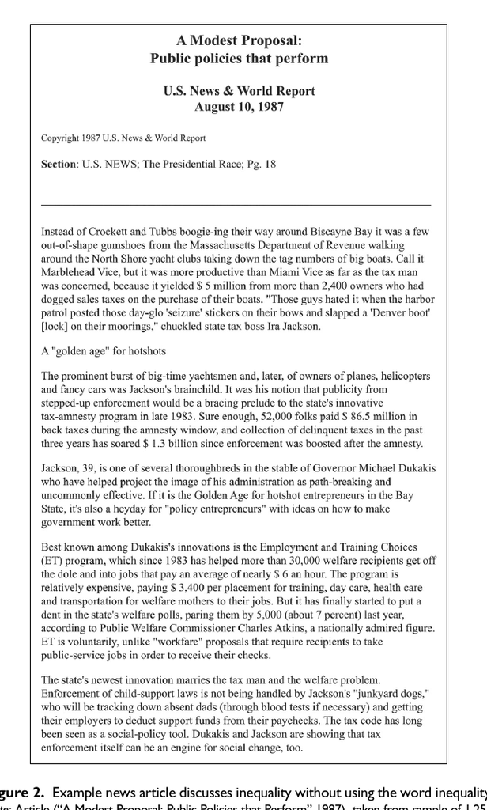

The article never uses the word *inequality*.

Human coders classified it as implicitly about inequality because it discusses tax enforcement, welfare policy, and economic distribution.

The model must apply a defined concept to a whole document—not merely retrieve a word.

Than et al. (2025), Figure 2.